# eta_prediction

```python
import numpy as np
import pandas as pd
import matplotlib.pyplot as plt
import seaborn as sns
from scipy.stats.mstats import winsorize
from sklearn.model_selection import train_test_split
from sklearn.metrics import mean_squared_error
from sklearn.metrics.pairwise import cosine_similarity
from sklearn.preprocessing import StandardScaler
from sklearn.impute import SimpleImputer
import lightgbm as lgb
from sklearn.ensemble import RandomForestRegressor
import keras
from keras.models import Sequential
from keras.layers import Dense
from keras import backend as K
import warnings
warnings.filterwarnings('ignore')
```

```python
df_train = pd.read_csv('Test - DS 2.csv')
df_test = pd.read_csv('Test-DS.csv')
df_train.drop('Unnamed: 0', axis=1, inplace=True)
df_test.drop('Unnamed: 0', axis=1, inplace=True)
```

Train:

- city_id - City in which task is created
- drop_area - Area from which user raised a task
- store_dzid - dunzo store id
- pickupareaid - Represents the Area from where dunzo partner needs to pickup
- store_name - name of the store. Two stores with different dzid can have the same names because they probably belong to the same food chain
- sub_tag - Kind of task Ex:- Food, Grocery, Pets
- task_created_on - Timestamp at task creation time
- accepted_time - Timestamp at dunzo delivery partner acceptance (NOT IN TEST)
- reached_for_pickup_time - Timestamp of dunzo partner reaching the store (NOT IN TEST)
- purchased_time - Timestamp at which partner successfully made a purchase of ordered items (NOT IN TEST)
- start_for_delivery_time - Timestamp at which partner started for delivery to the user from store or pickup location. (NOT IN TEST)
- reached_for_delivery_time - Timestamp at which partner reached the drop point or user address (NOT IN TEST)
- delivered_time - Timestamp at which partner successfully delivered the items (NOT IN TEST)
- rt_estimated_pickup_distance - estimated distance for partner to reach pickup point or store
- rt_estimated_task_distance - estimated distance from pickup point to drop point
- Target - subtract delivered_time timestamp from task_created_on timestamp

Any delivery partner related temporal attributes are not present in the test set. The task is to predict the ETA which is time taken from the point when the task was created to when it could get completed.

```python
display(df_train.head())
print('Shape of train data', df_train.shape)
display(df_test.head())
print('Shape of test data', df_test.shape)
```

|  | city_id | task_created_on | store_name | store_dzid | sub_tag | rt_estimated_pickup_distance | rt_estimated_task_distance | pickupareaid | drop_area | accepted_time | reached_for_pickup_time | purchased_time | start_for_delivery_time | reached_for_delivery_time | delivered_time |
| --- | --- | --- | --- | --- | --- | --- | --- | --- | --- | --- | --- | --- | --- | --- | --- |
| 0 | 4 | 01:13.9 | store0 | 0 | subtag2 | 0.025 | 2.13 | 1302.0 | drop_area0 | 14:05.0 | 14:10.0 | 20:58.0 | 21:09.0 | 27:46.0 | 29:04.0 |
| 1 | 1 | 24:33.4 | store1 | 1 | subtag1 | 1.362 | 0.23 | 1028.0 | drop_area1 | 24:47.0 | 29:16.0 | 39:32.0 | 43:44.0 | 44:29.0 | 44:58.0 |
| 2 | 1 | 12:57.0 | store2 | 2 | subtag1 | 0.876 | 2.05 | 997.0 | drop_area2 | 13:51.0 | 18:17.0 | 37:06.0 | 37:22.0 | 44:36.0 | 48:35.0 |
| 3 | 1 | 16:11.3 | store3 | 3 | subtag4 | 1.082 | 4.73 | 1006.0 | drop_area3 | 16:53.0 | NaN | NaN | NaN | NaN | NaN |
| 4 | 1 | 32:46.7 | store1 | 4 | subtag1 | 2.938 | 1.70 | 956.0 | drop_area4 | 33:16.0 | 46:47.0 | 49:06.0 | 49:13.0 | 01:50.0 | 10:52.0 |

```
Shape of train data (422956, 15)
```

|  | city_id | task_created_on | store_name | store_dzid | sub_tag | rt_estimated_pickup_distance | rt_estimated_task_distance | pickupareaid | drop_area |
| --- | --- | --- | --- | --- | --- | --- | --- | --- | --- |
| 0 | 1 | 17:32.3 | store3 | 93 | subtag4 | 0.910 | 1.80 | 994 | drop_area65 |
| 1 | 6 | 17:00.8 | store82 | 94 | subtag1 | 0.012 | 2.11 | 1332 | drop_area66 |
| 2 | 4 | 52:36.2 | store100 | 115 | subtag1 | 1.646 | 1.65 | 1241 | drop_area35 |
| 3 | 1 | 03:45.0 | store104 | 120 | subtag2 | 1.464 | 0.15 | 976 | drop_area82 |
| 4 | 5 | 34:01.9 | store17 | 123 | subtag2 | 0.005 | 0.01 | 1427 | drop_area17 |

```
Shape of test data (104684, 9)
```

```python
df_train.isnull().sum(axis=0)
```

```
city_id                             0
task_created_on                     0
store_name                          0
store_dzid                          0
sub_tag                             0
rt_estimated_pickup_distance        0
rt_estimated_task_distance          2
pickupareaid                       99
drop_area                           0
accepted_time                   23527
reached_for_pickup_time         34300
purchased_time                  40849
start_for_delivery_time         46287
reached_for_delivery_time       41822
delivered_time                  47508
dtype: int64
```

In order to calculate ETA, we need a complete fill rate on all temporal attributes so we need to discard observations that have these values missing. Why is this necessary? We could have just taken a difference between delivered_time and task_created_on, however, the assumption then would be that all tasks created get fulfilled in less than an hour. A more reasonable assumption is that the difference in times between each step in the task completion process is less than an hour. These steps are:

Task Created -> Accepted -> Reached For Pickup -> Purchased -> Start For Delivery -> Reached For Delivery -> Delivered

What we'll do below is calculate difference between each of these steps (successively) and then add up the times to create the target label. This process would have been a lot easier, if we had the day + hour in the timestamp

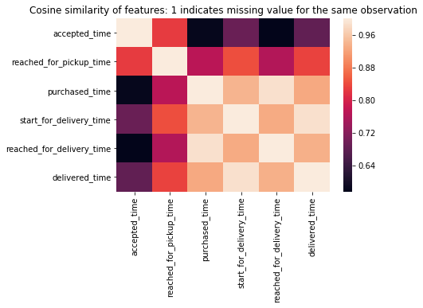

```python
temporal_cols = ['task_created_on',
                 'accepted_time',
                 'reached_for_pickup_time',
                 'purchased_time',
                 'start_for_delivery_time',
                 'reached_for_delivery_time',
                 'delivered_time']
plt.title('Cosine similarity of features: 1 indicates missing value for the same observation')
# This array is a boolean array that contains a True if the observation for the feature contains a missing value and False
# if it does not
missing_values = pd.isnull(df_train[temporal_cols[1:]]).values.T
sns.heatmap(cosine_similarity(missing_values), xticklabels=temporal_cols[1:], yticklabels=temporal_cols[1:])
```

The high cosine similarity is indicative of the fact that if any of our observations has a missing value for a given temporal column, then it is highly likely that it has a missing value for the other temporal columns as well

```python
%%time
def convert_timestamp(col):
    # Getting rid of the decimal point after seconds
    df_train[col] = df_train[col].apply(lambda x: x.split('.')[0])
    return(pd.to_datetime(df_train[col], format='%M:%S'))

# A very small number of values is missing in pickupareaid so we'll remove them as well
df_train = df_train.dropna(subset=temporal_cols + ['pickupareaid'])
for col in temporal_cols:
    df_train[col] = convert_timestamp(col)
for col_index in range(len(temporal_cols)-1):
    df_train['diff_'+str(col_index)] = df_train[temporal_cols[col_index+1]] - df_train[temporal_cols[col_index]]
    # To get target value in seconds. The if condition just takes care of those observations where time difference is -ve
    df_train['diff_'+str(col_index)] = df_train['diff_'+str(col_index)].apply(lambda x: (3600+x.total_seconds())
                                                                                        if x.days==-1 else x.total_seconds())
df_train['time_taken'] = df_train[[col for col in df_train.columns if 'diff' in col]].sum(axis=1)

# The temporal attributes in themselves have no predictive power since we don't have this data at an hour/day level
# where one would expect task completion times to be greater during peak hours and weekdays
df_train.drop(temporal_cols, axis=1, inplace=True)
df_test.drop('task_created_on', axis=1, inplace=True)
```

```
CPU times: user 33.3 s, sys: 769 ms, total: 34.1 s
Wall time: 34 s
```

```python
# The fill rate across all attributes is a 100% now
display(df_train.head())
display(df_test.head())
```

|  | city_id | store_name | store_dzid | sub_tag | rt_estimated_pickup_distance | rt_estimated_task_distance | pickupareaid | drop_area | diff_0 | diff_1 | diff_2 | diff_3 | diff_4 | diff_5 | time_taken |
| --- | --- | --- | --- | --- | --- | --- | --- | --- | --- | --- | --- | --- | --- | --- | --- |
| 0 | 4 | store0 | 0 | subtag2 | 0.025 | 2.13 | 1302.0 | drop_area0 | 772.0 | 5.0 | 408.0 | 11.0 | 397.0 | 78.0 | 1671.0 |
| 1 | 1 | store1 | 1 | subtag1 | 1.362 | 0.23 | 1028.0 | drop_area1 | 14.0 | 269.0 | 616.0 | 252.0 | 45.0 | 29.0 | 1225.0 |
| 2 | 1 | store2 | 2 | subtag1 | 0.876 | 2.05 | 997.0 | drop_area2 | 54.0 | 266.0 | 1129.0 | 16.0 | 434.0 | 239.0 | 2138.0 |
| 4 | 1 | store1 | 4 | subtag1 | 2.938 | 1.70 | 956.0 | drop_area4 | 30.0 | 811.0 | 139.0 | 7.0 | 757.0 | 542.0 | 2286.0 |
| 5 | 2 | store4 | 5 | subtag2 | 2.996 | 0.74 | 1099.0 | drop_area5 | 356.0 | 657.0 | 155.0 | 20.0 | 1318.0 | 11.0 | 2517.0 |

|  | city_id | store_name | store_dzid | sub_tag | rt_estimated_pickup_distance | rt_estimated_task_distance | pickupareaid | drop_area |
| --- | --- | --- | --- | --- | --- | --- | --- | --- |
| 0 | 1 | store3 | 93 | subtag4 | 0.910 | 1.80 | 994 | drop_area65 |
| 1 | 6 | store82 | 94 | subtag1 | 0.012 | 2.11 | 1332 | drop_area66 |
| 2 | 4 | store100 | 115 | subtag1 | 1.646 | 1.65 | 1241 | drop_area35 |
| 3 | 1 | store104 | 120 | subtag2 | 1.464 | 0.15 | 976 | drop_area82 |
| 4 | 5 | store17 | 123 | subtag2 | 0.005 | 0.01 | 1427 | drop_area17 |

```python
df_train[[col for col in df_train.columns if 'diff' in col]].describe()
```

|  | diff_0 | diff_1 | diff_2 | diff_3 | diff_4 | diff_5 |
| --- | --- | --- | --- | --- | --- | --- |
| count | 374543.000000 | 374543.000000 | 374543.000000 | 374543.000000 | 374543.000000 | 374543.000000 |
| mean | 110.376656 | 330.400640 | 349.561054 | 62.840219 | 548.095540 | 168.594765 |
| std | 218.875366 | 318.832751 | 370.272087 | 133.635650 | 407.736153 | 233.535901 |
| min | 0.000000 | 1.000000 | 3.000000 | 1.000000 | 0.000000 | 0.000000 |
| 25% | 19.000000 | 102.000000 | 101.000000 | 9.000000 | 283.000000 | 33.000000 |
| 50% | 27.000000 | 264.000000 | 226.000000 | 22.000000 | 455.000000 | 113.000000 |
| 75% | 78.000000 | 469.000000 | 469.000000 | 121.000000 | 696.000000 | 213.000000 |
| max | 3598.000000 | 3599.000000 | 3599.000000 | 3598.000000 | 3597.000000 | 3599.000000 |

diff_3 indicates the time it took for the delivery partner to start delivery after purchase of items. diff_5 indicates the time it took for him to deliver the product to the customer after he reached the delivery point. These values should intuitively be low. diff_1, diff_2, diff_4 have higher means than the other 3 attributes and they indicate time to pickup, time to purchase and time to reach delivery point respectively. We will also include diff_0 which is time taken to accept, in order to create features. Since we also have the target variable, we won't include the other 2 features. These values will be used to calculate mean encodings which have been explained in the feature engineering section.

```python
df_train.rename(columns={'diff_0':'time_to_accept',
                         'diff_1':'time_to_pickup',
                         'diff_2':'time_to_purchase',
                         'diff_4':'time_to_drop'}, inplace=True)
```

```python
common_cols = list(set(df_train.columns).intersection(set(df_test.columns)))
time_cols = [col for col in df_train.columns if 'time' in col]

# Preprocessing both train and test together
train_last_row = df_train.shape[0] # last row of the training data
df_data = pd.concat([df_train[common_cols + time_cols], df_test], axis=0, sort=True) #sorts column names

# Calculating total distance for the task
df_data['drop_area'] = df_data['drop_area'].apply(lambda x: x.split('drop_area')[1]).astype(int)
df_data['pickupareaid'] = df_data['pickupareaid'].astype(int)
df_data['store_name'] = df_data['store_name'].apply(lambda x: x.split('store')[1]).astype(int)
df_data['sub_tag'] = df_data['sub_tag'].apply(lambda x: x.split('subtag')[1]).astype(int)
df_data['total_distance'] = df_data['rt_estimated_pickup_distance'] + df_data['rt_estimated_task_distance']
df_data['time_to_pickup'] += 1 # To avoid zero divide errors
df_data['time_to_drop'] += 1 # To avoid zero divide errors
# These features compute speed in the pickupareaid/ drop_area
df_data['pickup_speed'] = df_data['rt_estimated_pickup_distance']/df_data['time_to_pickup']
df_data['drop_speed'] = df_data['rt_estimated_task_distance']/df_data['time_to_drop']

# Seperating train and test
df_train = df_data.iloc[:train_last_row]
df_test = df_data.iloc[train_last_row:]
```

```python
display(df_train.head())
display(df_test.head())
```

|  | city_id | drop_area | pickupareaid | rt_estimated_pickup_distance | rt_estimated_task_distance | store_dzid | store_name | sub_tag | time_taken | time_to_accept | time_to_drop | time_to_pickup | time_to_purchase | total_distance | pickup_speed | drop_speed |
| --- | --- | --- | --- | --- | --- | --- | --- | --- | --- | --- | --- | --- | --- | --- | --- | --- |
| 0 | 4 | 0 | 1302 | 0.025 | 2.13 | 0 | 0 | 2 | 1671.0 | 772.0 | 398.0 | 6.0 | 408.0 | 2.155 | 0.004167 | 0.005352 |
| 1 | 1 | 1 | 1028 | 1.362 | 0.23 | 1 | 1 | 1 | 1225.0 | 14.0 | 46.0 | 270.0 | 616.0 | 1.592 | 0.005044 | 0.005000 |
| 2 | 1 | 2 | 997 | 0.876 | 2.05 | 2 | 2 | 1 | 2138.0 | 54.0 | 435.0 | 267.0 | 1129.0 | 2.926 | 0.003281 | 0.004713 |
| 4 | 1 | 4 | 956 | 2.938 | 1.70 | 4 | 1 | 1 | 2286.0 | 30.0 | 758.0 | 812.0 | 139.0 | 4.638 | 0.003618 | 0.002243 |
| 5 | 2 | 5 | 1099 | 2.996 | 0.74 | 5 | 4 | 2 | 2517.0 | 356.0 | 1319.0 | 658.0 | 155.0 | 3.736 | 0.004553 | 0.000561 |

|  | city_id | drop_area | pickupareaid | rt_estimated_pickup_distance | rt_estimated_task_distance | store_dzid | store_name | sub_tag | time_taken | time_to_accept | time_to_drop | time_to_pickup | time_to_purchase | total_distance | pickup_speed | drop_speed |
| --- | --- | --- | --- | --- | --- | --- | --- | --- | --- | --- | --- | --- | --- | --- | --- | --- |
| 0 | 1 | 65 | 994 | 0.910 | 1.80 | 93 | 3 | 4 | NaN | NaN | NaN | NaN | NaN | 2.710 | NaN | NaN |
| 1 | 6 | 66 | 1332 | 0.012 | 2.11 | 94 | 82 | 1 | NaN | NaN | NaN | NaN | NaN | 2.122 | NaN | NaN |
| 2 | 4 | 35 | 1241 | 1.646 | 1.65 | 115 | 100 | 1 | NaN | NaN | NaN | NaN | NaN | 3.296 | NaN | NaN |
| 3 | 1 | 82 | 976 | 1.464 | 0.15 | 120 | 104 | 2 | NaN | NaN | NaN | NaN | NaN | 1.614 | NaN | NaN |
| 4 | 5 | 17 | 1427 | 0.005 | 0.01 | 123 | 17 | 2 | NaN | NaN | NaN | NaN | NaN | 0.015 | NaN | NaN |

## EDA

#### Q. How does the distribution of the target look like?

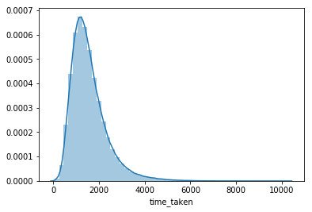

```python
sns.distplot(df_train['time_taken'])
```

This resembles a right-skewed normal distribution

```python
df_train['time_taken'].describe()
```

```
count    374543.000000
mean       1569.868875
std         788.483560
min          52.000000
25%        1034.000000
50%        1411.000000
75%        1921.000000
max       10278.000000
Name: time_taken, dtype: float64
```

The average time taken to complete a task is 26 minutes and the standard deviation is about 13 minutes. The question that we'll try to answer is, can we reduce this variability through ML or is this variability natural and cannot be explained?

#### Q. Is there any correlation between total_distance and target?

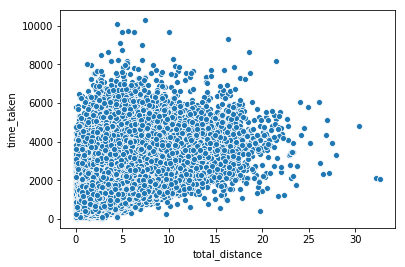

```python
sns.scatterplot(df_train['total_distance'], df_train['time_taken'])
```

```python
df_train[['total_distance','time_taken']].corr()
```

|  | total_distance | time_taken |
| --- | --- | --- |
| total_distance | 1.000000 | 0.537629 |
| time_taken | 0.537629 | 1.000000 |

There isn't a very high correlation. It is possible that some area codes are easier to service regardless of the distance due to higher frequency of riders, lesser traffic, faster store purchase times etc.

#### Q. How does the distribution of target variable look vs city_id?

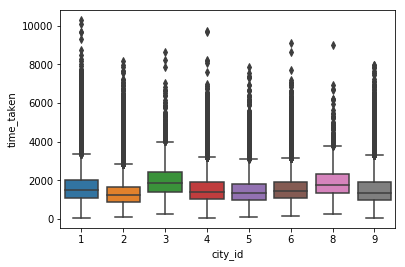

```python
sns.boxplot(df_train['city_id'], df_train['time_taken'])
```

```python
df_data.groupby('city_id')['time_taken'].describe()
```

| city_id | count | mean | std | min | 25% | 50% | 75% | max |
| --- | --- | --- | --- | --- | --- | --- | --- | --- |
| 1 | 156828.0 | 1645.833786 | 807.259171 | 69.0 | 1092.00 | 1483.0 | 2010.00 | 10278.0 |
| 2 | 64800.0 | 1385.146852 | 712.502332 | 89.0 | 906.00 | 1239.0 | 1676.00 | 8157.0 |
| 3 | 3476.0 | 2020.222670 | 891.389088 | 276.0 | 1405.75 | 1877.0 | 2439.00 | 8622.0 |
| 4 | 46115.0 | 1556.111460 | 760.105695 | 72.0 | 1038.00 | 1405.0 | 1900.00 | 9702.0 |
| 5 | 9168.0 | 1508.918630 | 797.321681 | 118.0 | 983.00 | 1339.0 | 1837.25 | 7857.0 |
| 6 | 46449.0 | 1586.092144 | 726.462172 | 131.0 | 1089.00 | 1443.0 | 1915.00 | 9129.0 |
| 8 | 2972.0 | 1895.127524 | 807.918848 | 276.0 | 1333.75 | 1762.5 | 2309.00 | 9017.0 |
| 9 | 44735.0 | 1524.359182 | 843.041715 | 52.0 | 960.00 | 1358.0 | 1894.00 | 7977.0 |

#### Q. How does the distribution of target variable look vs sub_tag?

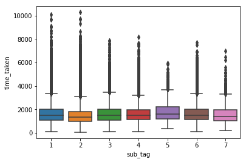

```python
sns.boxplot(df_train['sub_tag'], df_train['time_taken'])
```

```python
df_data.groupby('sub_tag')['time_taken'].describe()
```

| sub_tag | count | mean | std | min | 25% | 50% | 75% | max |
| --- | --- | --- | --- | --- | --- | --- | --- | --- |
| 1 | 110258.0 | 1661.032233 | 817.247538 | 89.0 | 1107.0 | 1489.0 | 2013.0 | 10089.0 |
| 2 | 191883.0 | 1484.050901 | 767.625085 | 52.0 | 961.0 | 1331.0 | 1827.0 | 10278.0 |
| 3 | 22138.0 | 1660.882645 | 808.238223 | 127.0 | 1096.0 | 1496.0 | 2040.0 | 7857.0 |
| 4 | 33272.0 | 1647.858710 | 733.312204 | 91.0 | 1144.0 | 1503.0 | 1976.0 | 8157.0 |
| 5 | 1896.0 | 1801.250527 | 833.002140 | 378.0 | 1210.0 | 1616.5 | 2206.5 | 5952.0 |
| 6 | 13461.0 | 1666.675210 | 793.933743 | 127.0 | 1130.0 | 1503.0 | 2015.0 | 7731.0 |
| 7 | 1635.0 | 1608.994495 | 802.430106 | 229.0 | 1055.0 | 1408.0 | 1954.0 | 6970.0 |

This plot looks similar to the one above. The mean/medians more aligned than city_id. sub_tag 1 and 2 account for majority of the observations (about 80%)

#### Q. Do both train and test sets contain the same city_id, drop_area, pickupareaid, store_dzid, store_name, sub_tag?

We also want to check if there are levels within categorical variables that are represented in test set but not train set

```python
def check_train_test(col):
    print('Number of unique', col, 'in train:', df_train[col].nunique())
    print('Number of unique', col, 'in test :', df_test[col].nunique())
    print('Number of', col,'in test that are not contained in train:', len(set(df_test[col]) - set(df_train[col])))
```

```python
categ_cols = ['city_id', 'drop_area', 'pickupareaid', 'store_dzid', 'store_name', 'sub_tag']
for col in categ_cols:
    check_train_test(col)
    print('\n')
```

```
Number of unique city_id in train: 8
Number of unique city_id in test : 8
Number of city_id in test that are not contained in train: 0


Number of unique drop_area in train: 252
Number of unique drop_area in test : 255
Number of drop_area in test that are not contained in train: 4


Number of unique pickupareaid in train: 249
Number of unique pickupareaid in test : 244
Number of pickupareaid in test that are not contained in train: 2


Number of unique store_dzid in train: 23477
Number of unique store_dzid in test : 10365
Number of store_dzid in test that are not contained in train: 6275


Number of unique store_name in train: 8215
Number of unique store_name in test : 4903
Number of store_name in test that are not contained in train: 1135


Number of unique sub_tag in train: 7
Number of unique sub_tag in test : 7
Number of sub_tag in test that are not contained in train: 0
```

As is evident, store_dzid and store_name have high cardinality and also have a lot of mismatch in levels between train and test sets. store_dzid has about 60% of levels that are not contained in train set whereas store_name has about 20%. For the other attributes, this is a very small number wrt the cardinality of the variable. The levels that are present in test but not in train are levels that have very low frequency. Such levels are also present in train but not in test. Since a small number of levels are responsible for majority of the observations, we can combine the low frequency levels under one bucket. These levels will be sorted from least to most frequent and the least frequent levels that have a cumulative frequency less than some threshold will be labeled as -1 or 'Other'. This has been discussed here (https://www.kaggle.com/c/bluebook-for-bulldozers/discussion/4066 and https://datascience.stackexchange.com/questions/37480/how-can-i-do-classification-with-categorical-data-which-is-not-fixed/37486)

```python
# Low frequency columns are labeled as -1
def high_freq_enc(col, thresh=0.9):
    high_freq_level = df_data[col].value_counts(normalize=True).cumsum() < thresh
    high_freq_level = high_freq_level[high_freq_level==True].index
    return(df_data[col].apply(lambda x: x if x in high_freq_level else -1))

# We perform this labeling/encoding on the combined data. This is to make sure low frequency columns in either data sets -
# test and train are labeled as -1.
col_thresh = {'drop_area':0.98, 'pickupareaid':0.98, 'store_dzid':0.9, 'store_name':0.9}
for col in ['drop_area', 'pickupareaid', 'store_dzid', 'store_name']:
    df_data[col] = high_freq_enc(col, col_thresh[col])

# Seperating train and test
df_train = df_data.iloc[:train_last_row]
df_test = df_data.iloc[train_last_row:]

# The above method takes care of low frequency levels in drop_area and pickupareaid.
# About 4 levels in store_dzid and 1 level in store_name still remain. These will now be replaced with -1
def replace_values(col):
    values_missing = list(set(df_test[col]) - set(df_train[col]))
    df_test[col] = df_test[col].replace(values_missing, -1)

# To replace values in other attributes
replace_values('store_dzid')
replace_values('store_name')
```

```python
categ_cols = ['city_id', 'drop_area', 'pickupareaid', 'store_dzid', 'store_name', 'sub_tag']
for col in categ_cols:
    check_train_test(col)
    print('\n')
```

```
Number of unique city_id in train: 8
Number of unique city_id in test : 8
Number of city_id in test that are not contained in train: 0


Number of unique drop_area in train: 196
Number of unique drop_area in test : 196
Number of drop_area in test that are not contained in train: 0


Number of unique pickupareaid in train: 160
Number of unique pickupareaid in test : 160
Number of pickupareaid in test that are not contained in train: 0


Number of unique store_dzid in train: 2071
Number of unique store_dzid in test : 2048
Number of store_dzid in test that are not contained in train: 0


Number of unique store_name in train: 837
Number of unique store_name in test : 833
Number of store_name in test that are not contained in train: 0


Number of unique sub_tag in train: 7
Number of unique sub_tag in test : 7
Number of sub_tag in test that are not contained in train: 0
```

#### Q. For the same combination of drop_area and pickupareaid, what is the distribution of std deviation of time_taken?

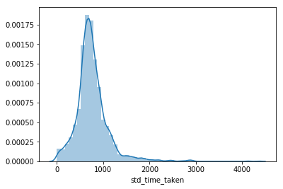

```python
sns.distplot(df_train.groupby(['drop_area','pickupareaid']).agg(std_time_taken=('time_taken','std'))['std_time_taken'].dropna())
```

```python
df_train.groupby(['drop_area','pickupareaid']).agg(std_time_taken=('time_taken','std'))['std_time_taken'].describe()
```

```
count    2704.000000
mean      759.272605
std       353.912622
min         0.707107
25%       580.567787
50%       717.071337
75%       885.505196
max      4347.292491
Name: std_time_taken, dtype: float64
```

This is an interesting plot. For the same combination of drop_area and pickupareaid, the distribution of the standard deviation of time_taken is right skewed and has a mean of 759. What this means is, given standard deviation of historical time_taken between two area codes, this distribution varies by 759 seconds on average, which is a little less than 13 minutes. If the time_taken was constant for two area codes, the standard deviation would have been 0, and consequently the average of standard deviations would also have been 0. Now an important follow up question is, does the standard deviation reduce if we also factor in the store_dzid?

#### Q. For the same combination of drop_area, pickupareaid AND store_dzid, what is the distribution of std deviation of time_taken?

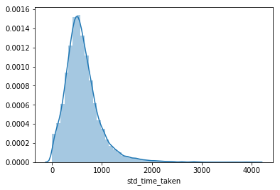

```python
sns.distplot(df_train.groupby(['drop_area','pickupareaid','store_dzid']).agg(std_time_taken=('time_taken','std'))['std_time_taken'].dropna())
```

```python
df_train.groupby(['drop_area','pickupareaid','store_dzid']).agg(std_time_taken=('time_taken','std'))['std_time_taken'].describe()
```

```
count    12804.000000
mean       604.497459
std        351.225291
min          0.707107
25%        383.124380
50%        548.952591
75%        756.800268
max       4080.006127
Name: std_time_taken, dtype: float64
```

It does. For the same combination of drop_area, pickupareaid and store_dzid, the average of standard deviation in time_taken has significantly reduced. This means that store_dzid has a significant effect on the time_taken. Why could this be important? The one factor that matters with respect to store_dzid is purchase time.

#### Q. How is time_to_purchase distributed?

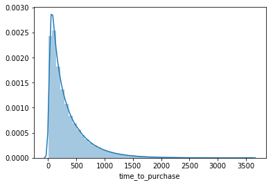

```python
sns.distplot(df_train['time_to_purchase'])
```

This resembles an exponential distribution where the probability that a delivery partner will take 'X' time to purchase, decreases as 'X' increases

```python
df_train['time_to_purchase'].describe()
```

```
count    374543.000000
mean        349.561054
std         370.272087
min           3.000000
25%         101.000000
50%         226.000000
75%         469.000000
max        3599.000000
Name: time_to_purchase, dtype: float64
```

The standard deviation of this distribution is about 370. Does this number decrease if we factor in store_dzid? If the time_to_purchase was the same every time a partner made a purchase at a particular store_dzid, then the standard deviation of time_to_purchase for that particular store_dzid would be 0. And if this was the case with every store_dzid, then the average of standard deviations would also be 0. We will create a plot of the standard deviation of time_to_purchase wrt store_dzid. How does this distribution look like?

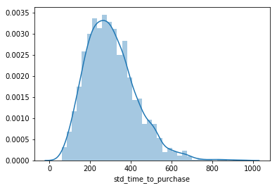

```python
sns.distplot(df_train.groupby(['store_dzid']).agg(std_time_to_purchase=('time_to_purchase','std'))['std_time_to_purchase'])
```

```python
df_train.groupby(['store_dzid']).agg(std_time_to_purchase=('time_to_purchase','std'))['std_time_to_purchase'].describe()
```

```
count    2071.000000
mean      304.553264
std       123.809062
min        61.289023
25%       214.599724
50%       289.438595
75%       374.292568
max       948.391941
Name: std_time_to_purchase, dtype: float64
```

The mean standard deviation is certainly lesser. This means purchase times are important with respect to store_dzid

## Feature Engineering

Mean encodings/ target encodings are values that are aggregates of target grouped by levels within categorical attribute(s). Since we do not have target values for the test set, what we can do is calculate them for the train set, store them in a dictionary and use them to map categorical attributes within the test set. In order to reduce overfitting, we will use a concept known as expanding mean. Expanding mean for a level within a categorical attribute considers cumulative sum of target value for all observations prior to the one it is being computed on (that belong to the level) and divides them by their cumulative count. Mean encodings help us create a lot of features and reduce the cardinality of the categorical variables. Some of the important questions that will help us create these mean encodings are listed below:

- What is the average target value vs drop_area?
- What is the average target value vs pickupareaid?
- What is the average target value for the combination of drop_area, pickupareaid?
- What is the average target value vs store_dzid?
- What is the average target value vs store_name?

Do some areas have more delivery partners than others? When a user raises a task, how much time do delivery partners closest to the pickupareaid take to accept the task. This can be answered by computing another feature:

- What is the average acceptance time vs pickupareaid?

Since we have also calculated time it takes for a partner to purchase items at a particular store, they can then be used to calculate more mean encodings. It is possible that some store chains are more efficient than others:

- What is the average purchase time vs store_dzid?
- What is the average purchase time vs store_name?

We have also computed a feature called speed (distance/time) for pickup and drop. We have been given estimated pickup and drop distance and by using time taken for the particular drop_area and pickupareaid, we can compute:

- What is the average speed vs pickupareaid?
- What is the average speed vs drop_area?

city_id and sub_task won't be used for creating mean encodings since there isn't a great difference in the average target variable for each city_id/sub_task

```python
# Function to calculate expanding mean
def exp_mean(list_cols, list_train):
    target = list_cols[-1]
    df = pd.concat(list_train, axis=1)
    cumsum = df.groupby(list_cols[:-1])[target].cumsum() - df[target]
    cumcnt = df.groupby(list_cols[:-1]).cumcount()
    return(cumsum/cumcnt)

# Function to calculate mean encoding on a given dataset and return a dictionary with the encodings
# If there is a list of columns, the dictionary will have a tuple as its key
def cal_mean_enc(list_cols, list_train):
    target = list_cols[-1]
    df = pd.concat(list_train, axis=1)
    mean_enc = df.groupby(list_cols[:-1]).agg(mean_enc=(target, 'mean')).to_dict()['mean_enc']
    return(mean_enc)

# Function to get key for the list of cols to which the mean encoding is applied. This key will be used to retrieve its
# mean encoding
def get_key(list_cols, df):
    first_col = list_cols[0]
    second_col = list_cols[1]
    return(list(zip(df[first_col], df[second_col])))

# This function combines the above 3 functions
def mean_encode(list_train, X_valid, features_to_engineer):
    for key, value in features_to_engineer.items():
        mean_enc = cal_mean_enc(value, list_train)
        X_train[key] = exp_mean(value, list_train)
        if len(value) > 2:
            X_valid[key] = get_key(value, X_valid)
            X_valid[key] = X_valid[key].map(mean_enc)
        else:
            X_valid[key] = X_valid[value[0]].map(mean_enc)
        print(key,'created!')
```

```python
# The validation set will contain about the same number of observations as the test set
# The split is random because there are no time dependent variables (at an hour or day level)
# Furthermore, an ML model was trained using cross validation on 5 folds and the std dev of scores across all folds was
# very less to warrant the fact that the data has no dependence on row number
X_train, X_valid, y_train, y_valid = train_test_split(df_train.drop('time_taken', axis=1), df_train['time_taken'],
                                                      test_size=0.25, random_state=42)
```

```python
# This dictionary contains as key, the features to create and the values contain the list of columns needed to create
# the feature
features_to_engineer = {'drop_area_enc':['drop_area','time_taken'],
                        'pickuparea_enc':['pickupareaid','time_taken'],
                        'drop_area_pickupareaid_enc':['drop_area','pickupareaid','time_taken'],
                        'store_dzid_enc':['store_dzid','time_taken'],
                        'store_name_enc':['store_name','time_taken'],
                        'pickupareaid_acc_enc':['pickupareaid','time_to_accept'],
                        'store_dzid_pur_enc':['store_dzid','time_to_purchase'],
                        'store_name_pur_enc':['store_name','time_to_purchase'],
                        'pickupareaid_speed_enc':['pickupareaid','pickup_speed'],
                        'drop_area_speed_enc':['drop_area','drop_speed']}
list_train = [X_train, y_train]
mean_encode(list_train, X_valid, features_to_engineer)
```

```
drop_area_enc created!
pickuparea_enc created!
drop_area_pickupareaid_enc created!
store_dzid_enc created!
store_name_enc created!
pickupareaid_acc_enc created!
store_dzid_pur_enc created!
store_name_pur_enc created!
pickupareaid_speed_enc created!
drop_area_speed_enc created!
```

```python
# Mean encodings create a few null values. This is because of the expanding mean where we won't have the value for the first
# time a level was observed. These values are very few in number (<<1%) and can be imputed with the mean for that feature.
# The model will not be biased
def impute(X_train, X_valid):
    imp = SimpleImputer(missing_values=np.nan, strategy='mean')
    imp.fit(X_train)
    X_cols = X_train.columns
    X_train = pd.DataFrame(imp.transform(X_train), columns=X_cols)
    X_valid = pd.DataFrame(imp.transform(X_valid), columns=X_cols)
    return(X_train, X_valid)

X_train, X_valid = impute(X_train, X_valid)
```

```python
# Discarding unnecessary columns
consider_cols = X_train.drop([col for col in X_train.columns if 'time' in col] + ['drop_speed','pickup_speed'], axis=1).columns
X_train = X_train[consider_cols]
X_train[categ_cols] = X_train[categ_cols].astype(int)
X_valid = X_valid[consider_cols]
X_valid[categ_cols] = X_valid[categ_cols].astype(int)
```

```python
# This is how our dataset looks prior to modeling
display(X_train.head())
display(X_valid.head())
```

|  | city_id | drop_area | pickupareaid | rt_estimated_pickup_distance | rt_estimated_task_distance | store_dzid | store_name | sub_tag | total_distance | drop_area_enc | pickuparea_enc | drop_area_pickupareaid_enc | store_dzid_enc | store_name_enc | pickupareaid_acc_enc | store_dzid_pur_enc | store_name_pur_enc | pickupareaid_speed_enc | drop_area_speed_enc |
| --- | --- | --- | --- | --- | --- | --- | --- | --- | --- | --- | --- | --- | --- | --- | --- | --- | --- | --- | --- |
| 0 | 1 | 131 | 919 | 0.776 | 4.66 | 112 | 97 | 2 | 5.436 | 1571.438169 | 1571.40234 | 1559.722536 | 1570.096475 | 1571.599133 | 110.565814 | 349.53789 | 350.055013 | 0.013418 | 0.006884 |
| 1 | 2 | 26 | 1103 | 2.100 | 1.19 | 1419 | 943 | 1 | 3.290 | 1571.438169 | 1571.40234 | 1559.722536 | 1570.096475 | 1571.599133 | 110.565814 | 349.53789 | 350.055013 | 0.013418 | 0.006884 |
| 2 | 6 | 66 | 1332 | 0.207 | 1.43 | 277 | 215 | 1 | 1.637 | 1571.438169 | 1571.40234 | 1559.722536 | 1570.096475 | 1571.599133 | 110.565814 | 349.53789 | 350.055013 | 0.013418 | 0.006884 |
| 3 | 6 | 103 | 1356 | 1.299 | 0.68 | 322 | 39 | 3 | 1.979 | 1571.438169 | 1571.40234 | 1559.722536 | 1570.096475 | 1571.599133 | 110.565814 | 349.53789 | 350.055013 | 0.013418 | 0.006884 |
| 4 | 1 | 36 | 919 | 0.564 | 0.41 | -1 | -1 | 2 | 0.974 | 1571.438169 | 2074.00000 | 1559.722536 | 1570.096475 | 1571.599133 | 359.000000 | 349.53789 | 350.055013 | 0.003979 | 0.006884 |

|  | city_id | drop_area | pickupareaid | rt_estimated_pickup_distance | rt_estimated_task_distance | store_dzid | store_name | sub_tag | total_distance | drop_area_enc | pickuparea_enc | drop_area_pickupareaid_enc | store_dzid_enc | store_name_enc | pickupareaid_acc_enc | store_dzid_pur_enc | store_name_pur_enc | pickupareaid_speed_enc | drop_area_speed_enc |
| --- | --- | --- | --- | --- | --- | --- | --- | --- | --- | --- | --- | --- | --- | --- | --- | --- | --- | --- | --- |
| 0 | 6 | 118 | 1346 | 1.809 | 3.52 | -1 | -1 | 2 | 5.329 | 1782.150510 | 1625.674252 | 1683.859649 | 1976.710062 | 1936.892309 | 68.407022 | 615.540144 | 557.412237 | 0.016125 | 0.007946 |
| 1 | 6 | 34 | 1316 | 2.168 | 0.75 | 1253 | 39 | 3 | 2.918 | 1615.544352 | 1625.113357 | 1446.158000 | 1636.412903 | 1740.032518 | 53.674868 | 589.600000 | 568.937736 | 0.005573 | 0.006243 |
| 2 | 2 | 44 | 1099 | 0.909 | 3.49 | 33 | 32 | 2 | 4.399 | 1725.322665 | 1525.211332 | 2164.887640 | 1144.187166 | 1144.187166 | 298.990301 | 98.032086 | 98.032086 | 0.007105 | 0.007745 |
| 3 | 6 | 173 | 1346 | 0.753 | 1.90 | 417 | 317 | 2 | 2.653 | 1771.146084 | 1625.674252 | 1777.171053 | 1446.424658 | 1446.424658 | 68.407022 | 137.941781 | 137.941781 | 0.016125 | 0.006087 |
| 4 | 1 | 94 | 962 | 1.343 | 2.63 | 1703 | 1112 | 2 | 3.973 | 1754.490022 | 1638.206006 | 1465.599022 | 1384.444444 | 1381.833718 | 98.442039 | 206.974537 | 206.692841 | 0.004494 | 0.006501 |

## Model Building

Since we need to predict expected time of arrival, I have used Mean Squared Error (MSE) as the loss function for all 3 machine learning models. There are tasks for which the time_taken is too high and it is possible that the time_taken as calculated for these tasks are not outliers. MSE is easier to optimize. Mean Absolute Error favors smaller values

Since we have about 6 categorical variables that have high cardinality, I have used 2 tree based models since they work much better than linear models/neural networks for data sets with a lot of categorical variables. Tree based models don't require you to one-hot encode the categorical variables which is necessary for linear models/neural networks. The 3 models that I have built are:

- LightGBM (Gradient Boosting) with all features
- Random Forest with only encoded features and continous variables (i.e no categorical variables)
- A 4 layer Neural Network trained on scaled encoded features and continous variables (i.e no categorical variables)

These 3 models are diverse (boosting, bagging and neural networks) and depending on the features they have been trained on, they learn differently. In order to reduce the variance in estimates, I have taken a simple weighted average of the 3 models (weights based on RMSE on the validation set). Sufficient amount of hyperparameter tuning has been done through random search

#### LightGBM

```
Training until validation scores don't improve for 10 rounds.
[150]	train's rmse: 630.277	valid's rmse: 627.444
[300]	train's rmse: 613.443	valid's rmse: 612.802
[450]	train's rmse: 608.216	valid's rmse: 609.592
[600]	train's rmse: 604.603	valid's rmse: 608.105
[750]	train's rmse: 601.787	valid's rmse: 607.399
[900]	train's rmse: 599.328	valid's rmse: 606.935
[1050]	train's rmse: 597.101	valid's rmse: 606.683
[1200]	train's rmse: 594.982	valid's rmse: 606.445
[1350]	train's rmse: 592.976	valid's rmse: 606.243
[1500]	train's rmse: 591.049	valid's rmse: 606.107
Early stopping, best iteration is:
[1510]	train's rmse: 590.928	valid's rmse: 606.1
```

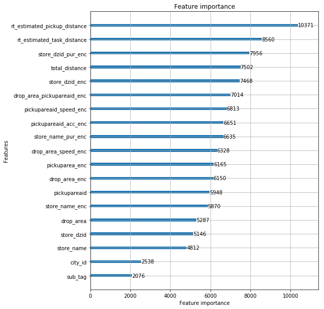

```python
# lightgbm regressor
lgb_regressor_params = {
               'feature_fraction': 0.75, # Proportion of features to be selected for each tree
               'metric': 'rmse',
               'nthread': 1,
               'min_data_in_leaf': 2**7, # Minimum data in one leaf
               'bagging_fraction': 0.75, # Proportion of observations to use when building a tree
               'learning_rate': 0.01, # Weightage given to every tree
               'objective': 'mse',
               'bagging_seed': 2**7,
               'num_leaves': 80, # LightGBM builds asymmetric trees. Thus even trees with less leaves can be very deep
               'bagging_freq':1, # Performs bagging at every iteration
               'verbose':0
              }
lgb_train = lgb.Dataset(X_train, label=y_train)
lgb_valid = lgb.Dataset(X_valid, label=y_valid)
# This model stops training if the validation scores don't improve successively for 10 iterations/ tree that is built
lgb_regressor = lgb.train(lgb_regressor_params, lgb_train, valid_sets=[lgb_train, lgb_valid],
                           valid_names=['train','valid'], verbose_eval=150, num_boost_round=2000, early_stopping_rounds=10)
lgb_valid = lgb_regressor.predict(X_valid)
# This plot shows the number of times a particular feature was used to create a split on a particular node/leaf of a tree
# summed over all trees
lgb.plot_importance(lgb_regressor, figsize=(8,10))
```

Store related encodings turn out to be very important. Interaction features such as drop_area_pickupareaid_enc, drop_area_speed_enc, pickupareaid_speed_enc are in the top 10 most important features

#### Random Forest

```
The rmse on validation set is 624.0344155822429
```

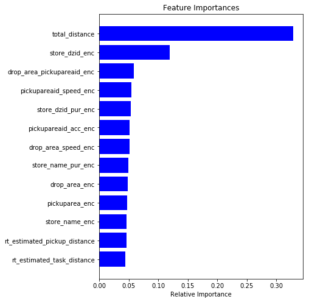

```python
# random forest regressor
rfr_regressor = RandomForestRegressor(n_estimators=100, criterion='mse', random_state=42, n_jobs=-1)
rfr_regressor.fit(X_train.drop(categ_cols, axis=1), y_train)
rfr_valid = rfr_regressor.predict(X_valid.drop(categ_cols, axis=1))
print('The rmse on validation set is', np.sqrt(mean_squared_error(y_valid, rfr_valid)))

features = X_train.drop(categ_cols, axis=1).columns
importances = rfr_regressor.feature_importances_
indices = np.argsort(importances)

# This plot shows the average decrease in impurity/ information gain over all trees in the forest
plt.figure(figsize=(6,8))
plt.title('Feature Importances')
plt.barh(range(len(indices)), importances[indices], color='b', align='center')
plt.yticks(range(len(indices)), [features[i] for i in indices])
plt.xlabel('Relative Importance')
```

Tree based models are biased towards pure continous features and categorical features with high cardinality as they have to create a lot of splits. This is the main reason why total_distance is far more important than the other features